# Weighting

Lecture 9C

PUBHBIO 6250

## Previous Example: SRS

- We previously saw that, in an SRS, the sample mean $\bar{y}$ is an **unbiased estimator** of the population mean

$$E(\bar{y}) = E \left(\frac{1}{n} \sum_{i=1}^{N} Z_i y_i \right) = \frac{1}{N} \sum_{i=1}^{N} y_i = \text{population mean}$$

- $Z_i$ = selection indicator
- All units equally likely to be selected
- All possible combinations of units could be selected, each combination with equal probability
- What if complex design features are involved?

## Imagine: A Stratified Sample

Imagine a population of $N=10,000$

- 10% of the population is in Group 1; Group 1 mean of $y$ = 10.0
- 90% of the population is in Group 2; Group 2 mean of $y$ = 15.0
- Population mean of $y$ = 14.5

**Thought experiment:**

What would happen if you took a stratified sample of $n=10$ from each group and estimated the population mean with the sample mean (averaged the 20 sampled units’ $y$ values)?

## Imagine: A Stratified Sample

*(true population mean = 14.5)*

**Sampling Distribution of $\bar{y}$**

*(average estimate = 12.5)*

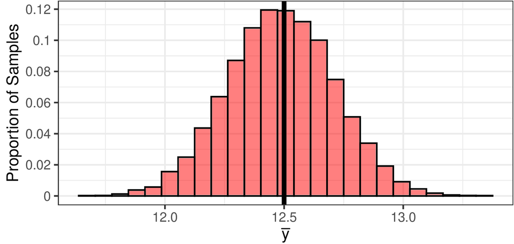

- The sample mean (average of sampled units) **underestimates** the true mean!
- Why? **Group 1 is over-represented in the sample**

**Good news:** We can obtain a better estimator – a **weighted** estimator – to account for the sampling design (stratification)

## Weighting

- Complex design features (clustering, stratification, PPS, etc.) $\rightarrow$ **means we cannot use the “usual” estimators** (e.g., $\bar{y}$)
- Must incorporate the selection probabilities $(\pi_i)$ into estimator
- This is accomplished through sampling weights:

**Sampling weight** = $\displaystyle w_i = \frac{1}{\pi_i}$ = inverse probability of selection

- Also called design weights or base weights
- Each unit $i$ in the sample “represents” $w_i$ units in the population
- Units more likely to be sampled (larger $\pi_i$) have smaller weights (smaller $w_i$) (and vice-versa)

## Example: Stratified Sample

- Selection probabilities are known for all units
- Units are chosen at random via SRS within stratum:
  - Stratum 1: $\pi_{1i} = P(\text{square } i \text{ selected}) = \textcolor{#0000FF}{n_1/N_1 = 4/12 = 1/3}$
  - Stratum 2: $\pi_{2i} = P(\text{circle } i \text{ selected}) = \textcolor{#0000FF}{n_2/N_2 = 4/8 = 1/2}$

## Example: Stratified Sample

- Stratum 1: $\pi_{1i} = 1/3 \rightarrow w_{1i} = \frac{1}{\pi_{1i}} = \frac{1}{1/3} = 3$
  - each sampled square “represents” **3** squares
- Stratum 2: $\pi_{2i} = 1/2 \rightarrow w_{2i} = \frac{1}{\pi_{2i}} = \frac{1}{1/2} = 2$
  - each sampled circle “represents” **2** circles
- Sum of the weights for all sampled units (squares and circles) =

$$\underbrace{3 + 3 + 3 + 3}_{\text{squares}} + \underbrace{2 + 2 + 2 + 2}_{\text{circles}} = 12 + 8 = 20 \text{ (population size $N$)}$$

## Example: Stratified Sample

- Stratum 1: $w_{1i} = 3$
- Stratum 2: $w_{2i} = 2$
- Estimated **total number vaccinated** () = $7$

$$\sum_{i=1}^{8} w_i \times y_i = \underbrace{3 \times 0 + 3 \times 1 + 3 \times 0 + 3 \times 0}_{\text{stratum 1}} + \underbrace{2 \times 1 + 2 \times 1 + 2 \times 0 + 2 \times 0 }_{\text{stratum 2}} = 7$$

## The Horvitz-Thompson Estimator

- We just calculated the **Horvitz-Thompson estimator** of the total:

$$\text{Estimated total of }y = \hat{t}_y = \sum_{i \in \mathcal{S}} w_i y_i \quad \text{(summing over the whole sample } \mathcal{S})$$

- To estimate the mean – divide by the total population size, $N$

$$\text{Estimated mean of }y = \frac{\text{est.\ total of $y$}}{\text{population size}} = \frac{\hat{t}_y}{N} = \frac{\sum_{i \in \mathcal{S}} w_i y_i }{N}$$

- Remember that proportions are means (of 0/1 variables)

## Example: Stratified Sample

- Stratum 1: $w_{1i} = 3$
- Stratum 2: $w_{2i} = 2$
- Estimated **total number vaccinated** () = 7 = $\hat{t}_y$
- Estimated **proportion vaccinated** () = $\dfrac{\text{estimated total}}{\text{population size}} = \dfrac{\hat{t}_y}{N} = \dfrac{7}{20} = 0.35$
- Compare to the unweighted proportion in the sample: $3/8 = 0.375$ (**biased**)

## The Hájek Estimator

- The sum of the sampling weights estimates the total population size, $N$
  - Sometimes (like in the example), $\displaystyle \sum_{i \in \mathcal{S}} w_i = N$, but not always
- This leads to a slightly different estimator for the mean of $y$, the **Hájek Estimator**:

$$\text{Estimated mean of }y = \frac{\text{est.\ total of $y$}}{\text{est.\ population size}} = \frac{\hat{t}_y}{\hat{N}} = \frac{\sum_{i \in \mathcal{S}} w_i y_i }{\sum_{i \in \mathcal{S}} w_i}$$

- When would we use this estimator?
  - For some sampling designs, we don’t know the population size ahead of time
  - With publicly available data, $N$ is not provided – have to use $\hat{N}$
  - It’s the default in most software

## Weighting in More Complex Designs

- For more complex designs (e.g., multistage), rules about conditional probability are used to calculate overall selection probabilities
- Suppose we have a 3-stage design – sampling PSUs, then SSUs, then TSUs

$$\begin{aligned}
P(\text{TSU }k\text{ in SSU }j\text{ in PSU }i\text{ selected}) &= P(\text{PSU }i\text{ selected}) \\
&\quad\times P(\text{SSU }j\text{ selected }|\text{ PSU }i\text{ selected})\\
&\qquad\times P(\text{TSU }k\text{ selected }|\text{ PSU }i\text{ and SSU }j\text{ selected}) \\
\text{selection probability} &= \pi_{i} \times \pi_{j|i} \times \pi_{k|ij} = \pi_{ijk}
\end{aligned}$$

- Thus the weight is $w_{ijk} = 1 / \pi_{ijk}$
- Note: probabilities at each stage are known by design (e.g., take SRS of PSUs)
- **You don’t need to calculate these (unless you’re the survey designer!)** – but you should know that the weights are created this way

## Post-Survey Weighting Adjustments

- These weights $w_i$ are the design weights, or base weights
- Often post-survey adjustments to these weights are done for several reasons:
  - Align estimated totals from the sample with known population totals
  - Adjust for nonresponse
  - Account for under- or over-coverage
  - Account for eligibility
  - Reduce the impact of very large sampling weights (weight trimming)
  - Dual-frame adjustment (e.g., when cell phone and landline frames overlap)
- Techniques to make some of these adjustments that you may encounter include post-stratification and raking/iterative proportional fitting
- Ultimately, **these adjustments will have already been made in publicly available survey data** and you will use **final weights**

## Always Use the Weights!

- Weights are necessary to produce **unbiased** estimates
- Reminder: **unbiased** is in terms of **repeated sampling**:
  - *If we repeatedly take samples using the exact same sampling method from the same population, and calculate the weighted estimate for each one, the average of all those (weighted) estimates will be the population truth*
- Weights especially important when design includes **oversampling of subgroups** or when **nonresponse occurs differentially across groups**
- Example: 2022 Ohio Pregnancy Assessment Survey
  - Outcome: Pregnancy was intended
  - Non-Hispanic Black mothers, who report lower rates of intendedness, have larger (adjusted) sampling weights
  - $\rightarrow$ Weighted estimate = 61% $<$ Unweighted estimate = 64%

## Back to the Imaginary Scenario

- Population mean of $y$ = 14.5
- Stratified sample of $n=10$ from each group
- (Unweighted) sample mean badly biased

The **weighted mean** – based on the sampling design – is unbiased:

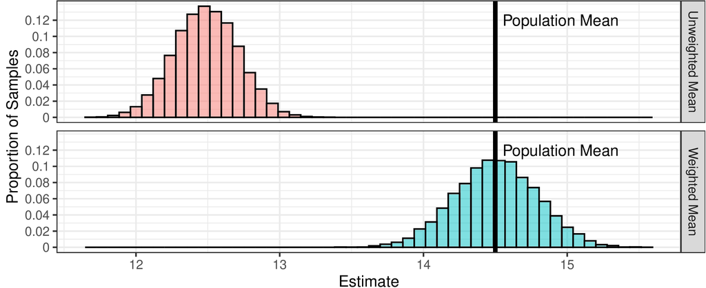

Challenge: Can you figure out what the sampling weights are for units in each group?